# Spectral Signature Analysis Plan — Laser Configuration & Fixation

6-laser vs 5-laser (Sony ID7000) across fixation treatments

Author

Flow Cytometry Panel Design

Published

September 14, 2026

# Analysis sets

The project contains **three primary bead-experiment analysis sets**:

- **56c** — 56-color experiment
- **90c** — 90-color experiment
- **83c** — 83-color experiment

Each experiment was acquired using both **5L and 6L instrument configurations**, with fluorochromes evaluated under four conditions: **Unfixed, 1% PFA, 4% PFA, and Perm**.

The same analysis workflow for **Question 1 (instrument configuration)** and **Question 2 (fixation impact)** will first be applied to each of the three experiment sets separately. The experiment identifier will be retained throughout the analysis rather than pooling the experiments at the start.

After the three primary analyses are complete, a **combined/validation summary** will compare results across experiments. Fluorochromes measured in more than one experiment can be used to assess consistency and reproducibility across datasets.

**Planned structure: 3 primary analysis sets (56c, 90c, 83c) + 1 combined/validation summary.**

# Analysis workflow

The same analysis workflow is first applied to the **56c experiment**, then repeated for the **90c** and **83c** experiments. Results are subsequently compared across experiments, including validation of fluorochromes measured in more than one experiment.

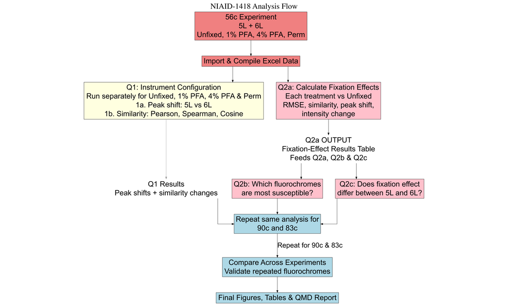

Figure 1: NIAID-1418 analysis workflow.

# Project questions

The analysis is organized around the specific questions defined by the collaborators. For each question below, the plan states **exactly what is being compared, how the quantity is calculated, what one result represents, and how the result will be interpreted**.

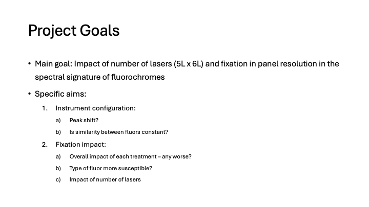

Figure 2: Collaborator slide 5 — Project goals and specific questions.

## Instrument configuration — 5L vs 6L

### Question 1a — Do spectral peaks shift?

**Question.** For the same fluorochrome, does the location of its highest spectral peak change between 5L and 6L?

**What is compared.** One fluorochrome is compared with **itself** under the two instrument configurations, within the same fixation treatment and experiment.

**Measurement.** Find the channel/wavelength containing the maximum spectral signal in 5L and the channel/wavelength containing the maximum spectral signal in 6L. Then calculate:

When wavelength mapping is available, peak shift will be reported in nm; otherwise it will be reported as a detector/channel shift. The primary quantity is the **horizontal movement of the peak location**, not a change in peak height.

**Interpretation.** A value of 0 means the highest peak did not move. A non-zero value means the peak moved, and the sign/direction indicates which way it moved.

**Outputs.** Per-fluorochrome peak locations in 5L and 6L, peak-shift tables, distributions of peak shifts, and plots marking the two peak locations.

### Question 1b — Is similarity between fluorochromes constant?

**Question.** For each pair of different fluorochromes, does their spectral similarity remain the same between 5L and 6L?

**What is compared.** Two different fluorochromes (for example, Fluor A and Fluor B) are compared with each other within 6L, and the **same pair** is then compared within 5L. This is performed separately within each fixation treatment and experiment.

**Measurements.** Three pairwise similarity measures will be calculated separately:

1. **Pearson correlation** — measures how closely the two spectral profiles follow the same linear pattern across detector channels.
2. **Spearman correlation** — measures whether the two spectra have a similar ranked pattern of high and low detector signals.
3. **Cosine similarity** — measures how similar the overall direction/shape of the two spectral vectors is.

For every fluorochrome pair and metric, there will therefore be one similarity value in 6L and one in 5L. The scatterplot uses:

`x = pairwise similarity in 6L`

`y = pairwise similarity in 5L`

The change in that pair’s relationship is also calculated as:

`Delta similarity = similarity in 5L - similarity in 6L`

and the magnitude of change is:

`|Delta similarity| = |similarity in 5L - similarity in 6L|`

**Interpretation.** Each scatterplot point is **one fluorochrome pair**. A point near the diagonal means the pair has similar similarity values in 5L and 6L. A point far from the diagonal has a large |Delta similarity| and therefore a configuration-sensitive relationship. Points will be colored by |Delta similarity|. Large changes can then be summarized across all pairs containing a given fluorochrome to identify fluorochromes whose relationships are especially configuration-sensitive.

**Outputs.** Separate Pearson, Spearman, and cosine 6L-vs-5L scatterplots colored by absolute change in similarity, pairwise change rankings, and per-fluorochrome summaries of configuration sensitivity.

## Fixation impact

### Question 2a — Does one fixation treatment have a greater overall impact?

**Question.** Which fixation treatment changes fluorochrome spectral signatures the most overall?

**What is compared.** Each fluorochrome under **1% PFA, 4% PFA, or Perm** is compared with the **same fluorochrome under Unfixed**, within the same laser configuration and experiment.

**Measurements.** Fixation effect is not a single undefined number. It will be quantified using complementary measurements because fixation can alter a spectrum in different ways:

- **RMSE** — measures the overall magnitude of the difference between the treated and Unfixed spectral values across detector channels. Smaller RMSE = less overall change; larger RMSE = more overall change.
- **Pearson correlation** — measures preservation of the linear spectral pattern relative to Unfixed. Values closer to 1 indicate greater similarity.
- **Spearman correlation** — measures preservation of the ranked pattern of detector signals relative to Unfixed. Values closer to 1 indicate greater similarity.
- **Cosine similarity** — measures preservation of the overall spectral-vector direction/shape relative to Unfixed. Values closer to 1 indicate greater similarity.
- **Maximum absolute detector difference** — the largest treated-vs-Unfixed difference observed at any single detector/channel.
- **Total intensity change** — summarizes whether the total signal across the spectrum increased or decreased relative to Unfixed.
- **Peak shift** — compares the treated and Unfixed locations of the highest spectral peak.

**Interpretation.** A treatment that repeatedly produces larger RMSE, larger maximum differences, larger intensity/peak changes, and/or lower similarity to Unfixed is more disruptive. The metrics will be examined together rather than calling one treatment worse from an undefined composite effect.

**Outputs.** Treatment-effect tables, fluorochrome-by-treatment heatmaps, distributions of each effect metric by treatment, and treatment rankings for each metric.

### Question 2b — Are particular types of fluorochromes more susceptible?

**Question.** Are some fluorochromes consistently more affected by fixation, and can susceptibility be associated with fluorochrome characteristics?

**What is compared.** The **per-fluorochrome fixation measurements calculated in Question 2a** are used here. For each fluorochrome, its changes under 1% PFA, 4% PFA, and Perm are summarized rather than calculating a new undefined “susceptibility” value.

**Measurement.** Fluorochromes will first be ranked separately using the 2a metrics (for example, high RMSE or low treated-vs-Unfixed similarity indicates stronger susceptibility). A transparent per-fluorochrome summary can then be created across treatments. If an agreed fluorochrome classification is available, these measured effects will also be compared among groups such as fluorochrome chemistry or excitation/emission ranges.

**Interpretation.** A fluorochrome that repeatedly shows large treated-vs-Unfixed changes across treatments/metrics is more fixation-sensitive. Group-level results will only be interpreted after the project team confirms the relevant classification metadata.

**Outputs.** Ranked fluorochrome susceptibility tables, fluorochrome-by-treatment heatmaps, metric-specific rankings, and group-level comparisons when approved classification metadata are available.

### Question 2c — Does laser configuration change the fixation effect?

**Question.** Does the effect of fixation on the same fluorochrome differ between the 5L and 6L configurations?

**What is compared.** For one fluorochrome and one treatment, first compare **Treated vs Unfixed under 5L**. Then make the same **Treated vs Unfixed comparison under 6L**. Finally compare those two measured fixation effects. This is repeated for each treatment, fluorochrome, and experiment.

**Measurement.** The fixation effect must be compared using the **same metric on both configurations**. For example, using RMSE:

`5L fixation effect = RMSE(5L treated, 5L Unfixed)`

`6L fixation effect = RMSE(6L treated, 6L Unfixed)`

`configuration-dependent fixation effect = 6L RMSE - 5L RMSE`

The same logic can be applied separately to the other 2a measurements. For similarity metrics, the direction is interpreted carefully because lower correlation/cosine means more disruption. Peak shift and intensity change are also compared using their own units rather than combining unlike metrics into a single score.

**Interpretation.** If the 5L and 6L fixation effects are similar, laser configuration has little influence on that treatment’s effect for that fluorochrome. A large difference means the fixation effect depends on laser configuration. This is the **laser configuration × fixation treatment** interaction of interest.

**Outputs.** For each fixation metric, 5L-vs-6L effect scatterplots, treatment-by-configuration heatmaps, and ranked fluorochromes with the largest configuration-dependent fixation effects.

## Analysis roadmap

| Question | Exact comparison | Measurement |
| --- | --- | --- |
| **1a** | Same fluorochrome: 5L vs 6L | Highest peak location; peak shift in nm/channel |
| **1b-i** | Fluor A vs Fluor B in 6L, then same pair in 5L | Pearson correlation + Delta similarity |
| **1b-ii** | Fluor A vs Fluor B in 6L, then same pair in 5L | Spearman correlation + Delta similarity |
| **1b-iii** | Fluor A vs Fluor B in 6L, then same pair in 5L | Cosine similarity + Delta similarity |
| **2a** | Same fluorochrome: each treatment vs Unfixed | RMSE, Pearson, Spearman, cosine, max difference, intensity change, peak shift |
| **2b** | Compare the measured 2a effects among fluorochromes/groups | Metric-specific susceptibility rankings |
| **2c** | Same fluor + treatment: fixation effect in 5L vs fixation effect in 6L | Difference in the same 2a metric between configurations |

# Purpose and scope

This report translates the five project questions above into a reproducible analysis workflow. The analyses are organized first around **instrument configuration (Questions 1a–1b)**, followed by **fixation effects (Questions 2a–2c)**.

The main project goal is to determine the impact of **laser count (5L vs 6L)** and **fixation treatment** on the spectral signatures of fluorochromes on the Sony ID7000.

The report includes worked analysis code and example outputs for the instrument-configuration questions, while establishing the planned framework for the fixation analyses.

**Important**

**Please make sure any requested changes, decisions, or updates is done by email or text from the PI so they can be clearly tracked. Changes discussed during meetings or verbal conversations is harder/impossible to track and reference later.**

# Collaborator-provided experimental context

The following figures are taken directly from the collaborator’s summary presentation and are embedded here so the analysis plan stays tied to the experimental design and instrument setup.

## Spectral flow cytometry concept

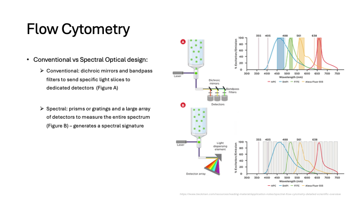

Figure 3: Collaborator slide 2 — Conventional versus spectral optical design and generation of a full spectral signature.

## Sony ID7000: 5L versus 6L configuration

The collaborator presentation specifies that the Sony ID7000 is being compared in **5-laser (147-channel)** and **6-laser (182-channel)** configurations.

[figure not shown]

Figure 4: Collaborator slide 3 — Sony ID7000 5-laser and 6-laser configurations.

## Experimental design

The three major bead experiments are acquired in both instrument configurations, with each fluorochrome measured under four conditions: **Unfixed, 1% PFA, 4% PFA, and Perm**.

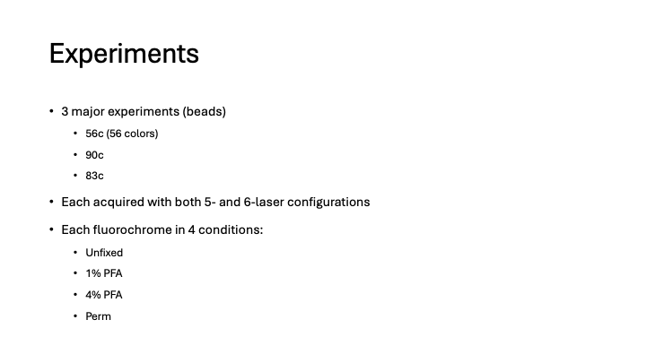

Figure 5: Collaborator slide 6 — Experiment structure across 5L/6L and four fixation conditions.

# Data loading

The parser follows the workbook layout: the header row is the one with `"Channels"` in column D, dye names are in columns E onward, numeric channel rows follow, and column B carries the `"<laser nm>-<detector>"` key used to identify each laser and to align channels across the two files.

```r
read_sheet_raw <- function(path, sheet) {
  read_excel(path, sheet = sheet, col_names = FALSE,
             .name_repair = "minimal", trim_ws = FALSE)
}

parse_sheet <- function(path, sheet, config) {
  raw <- read_sheet_raw(path, sheet)
  d <- trimws(as.character(raw[[4]]))
  h <- which(d == "Channels")[1]
  if (is.na(h)) stop(sprintf("No 'Channels' header in %s / %s", config, sheet))

  names0 <- trimws(as.character(unlist(raw[h, 5:ncol(raw), drop = FALSE])))
  fmap <- data.frame(col_index = 5:ncol(raw), fluorochrome = names0,
                     stringsAsFactors = FALSE) |>
    filter(!is.na(fluorochrome), fluorochrome != "")
  fmap$display_name <- make.unique(fmap$fluorochrome, sep = " [rep ")

  cand <- seq.int(h + 1, nrow(raw))
  dnum <- suppressWarnings(as.numeric(as.character(raw[[4]][cand])))
  rows <- cand[!is.na(dnum) & dnum >= 1 & dnum <= 320]

  mat <- matrix(NA_real_, nrow = length(rows), ncol = nrow(fmap),
                dimnames = list(NULL, fmap$display_name))
  for (j in seq_len(nrow(fmap)))
    mat[, j] <- suppressWarnings(as.numeric(as.character(raw[[fmap$col_index[j]]][rows])))

  channel_b <- trimws(as.character(raw[[2]][rows]))
  channels <- data.frame(
    Channel_B = channel_b,
    ChannelNumber = suppressWarnings(as.numeric(as.character(raw[[4]][rows]))),
    Laser = trimws(sub("-.*$", "", channel_b)),
    ChannelKey = channel_b,
    stringsAsFactors = FALSE
  )

  list(sheet = sheet, config = config,
       label = paste(config, sub(" Compil.*$", "", sheet), sep = " | "),
       matrix = mat, channels = channels, fluor_map = fmap)
}

load_config <- function(path, config) {
  if (!file.exists(path)) {
    warning(sprintf("File not found: %s", path)); return(list())
  }
  s <- excel_sheets(path)
  setNames(lapply(s, function(nm) parse_sheet(path, nm, config)),
           paste(config, sub(" Compil.*$", "", nm <- s), sep = " | "))
}

infos_6l <- load_config(params$file_6l, "6L")
infos_5l <- load_config(params$file_5l, "5L")
infos <- c(infos_6l, infos_5l)

preprocess_matrix <- function(mat, method) {
  out <- mat
  if (method == "Max normalize each fluorochrome")
    for (j in seq_len(ncol(out))) {
      m <- max(abs(out[, j]), na.rm = TRUE)
      if (is.finite(m) && m > 0) out[, j] <- out[, j] / m
    }
  if (method == "Z-score each fluorochrome")
    for (j in seq_len(ncol(out))) {
      x <- out[, j]; s <- sd(x, na.rm = TRUE); mu <- mean(x, na.rm = TRUE)
      out[, j] <- if (is.finite(s) && s > 0) (x - mu) / s else 0
    }
  out
}
```

```r
audit <- lapply(infos, function(p) data.frame(
  Condition = p$label, Config = p$config,
  Channels = nrow(p$matrix), Dyes = ncol(p$matrix),
  Lasers = length(unique(p$channels$Laser))
)) |> bind_rows()

kable(audit, caption = "Loaded conditions: channel and dye counts per config x treatment.")
```

Loaded conditions: channel and dye counts per config x treatment.

| Condition | Config | Channels | Dyes | Lasers |
| --- | --- | --- | --- | --- |
| 6L \| 6L Unfix | 6L | 182 | 145 | 6 |
| 6L \| 6L 1PFA | 6L | 182 | 145 | 6 |
| 6L \| 6L 4PFA | 6L | 182 | 145 | 6 |
| 6L \| 6L Perm | 6L | 182 | 145 | 6 |
| 5L \| 5L Unfix | 5L | 147 | 145 | 5 |
| 5L \| 5L 1PFA | 5L | 147 | 145 | 5 |
| 5L \| 5L 4PFA | 5L | 147 | 145 | 5 |
| 5L \| 5L Perm | 5L | 147 | 145 | 5 |

The 6L conditions carry the extra deep-UV detectors; the 5L conditions do not. Every cross-configuration comparison below is therefore restricted to the **shared channel set** (matched on the column-B key), so a 6L signature and a 5L signature are compared on the same axis.

When the real 5L data arrive, this channel matching will be validated against the actual laser/detector/wavelength metadata. Column-B keys are used here as a working alignment for software testing, not as an assumption that the final 5L and 6L layouts are biologically equivalent by position.

```r
keys_6l <- Reduce(intersect, lapply(infos_6l, \(p) p$channels$ChannelKey))
keys_5l <- Reduce(intersect, lapply(infos_5l, \(p) p$channels$ChannelKey))
shared_keys <- intersect(keys_6l, keys_5l)

uv_keys <- keys_6l[sub("-.*$", "", keys_6l) == params$uv_laser]

cat(sprintf("6L channels: %d | 5L channels: %d | shared: %d | UV-only (%s nm): %d\n",
            length(keys_6l), length(keys_5l), length(shared_keys),
            params$uv_laser, length(uv_keys)))
```

```
6L channels: 182 | 5L channels: 147 | shared: 147 | UV-only (320 nm): 35
```

```r
restrict_to_keys <- function(p, keys) {
  idx <- match(keys, p$channels$ChannelKey)
  ok <- !is.na(idx); idx <- idx[ok]
  p$matrix <- p$matrix[idx, , drop = FALSE]
  p$channels <- p$channels[idx, , drop = FALSE]
  p
}

# common dye list across all conditions
common_dyes <- Reduce(intersect, lapply(infos, \(p) unique(p$fluor_map$fluorochrome)))
cat(sprintf("Fluorochromes common to all conditions: %d\n", length(common_dyes)))
```

```
Fluorochromes common to all conditions: 140
```

# Question 1a — Peak shift between 5L and 6L

## Why automate peak detection?

The collaborator’s example shows that spectral-signature plots are useful for visual inspection, but small discrete changes — including a peak moving by a single channel — can be difficult to identify consistently by eye. The analysis below therefore makes peak identification explicit and reproducible.

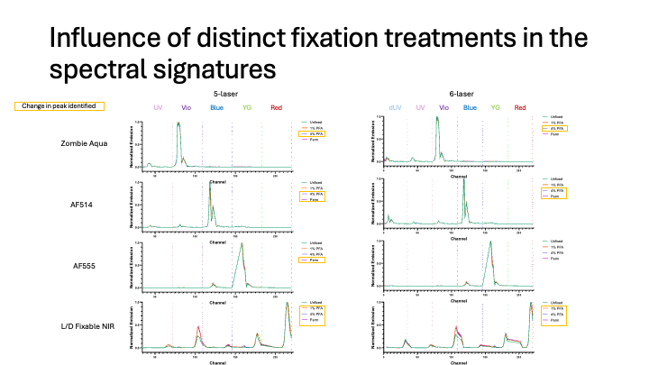

Figure 6: Collaborator slide 11 — Examples of fixation-associated spectral changes and the motivation for automated peak-shift detection.

**Primary question.** For each fluorochrome, does the location of its **highest spectral peak** change between the 5-laser and 6-laser configurations?

**Simple explanation.** Find the highest peak for the same fluorochrome in 5L and 6L and compare where those two peaks occur. If they occur at different wavelengths/channels, the peak has shifted.

For example:

- 5L highest peak = 575 nm
- 6L highest peak = 590 nm
- Peak shift = +15 nm

If the highest peak occurs at 575 nm in both configurations, the peak shift is 0 nm.

**Method.** For each fluorochrome and each fixation treatment:

1. Find the maximum spectral signal in the 5L signature and record its wavelength/channel.
2. Find the maximum spectral signal in the 6L signature and record its wavelength/channel.
3. Compare the two peak locations.
4. If the locations differ, calculate the magnitude and direction of the peak shift.

Where a direct wavelength mapping is available, report the shift in wavelength (nm). Otherwise, report the matched detector/channel change.

A secondary 6L-only diagnostic is also shown below: whether the 6L peak falls in the deep-UV block that is absent from the 5L configuration. This is useful for software/data inspection, but it is not interpreted as a biological 5L result without the real re-acquired 5L dataset.

```r
# peak channel key of a dye in a condition (optionally restricted to keys)
peak_key <- function(p, dye, method, keys = NULL) {
  if (!is.null(keys)) p <- restrict_to_keys(p, keys)
  dn <- p$fluor_map$display_name[p$fluor_map$fluorochrome == dye][1]
  if (is.na(dn) || !dn %in% colnames(p$matrix)) return(NA_character_)
  v <- preprocess_matrix(p$matrix, method)[, dn]
  if (all(!is.finite(v))) return(NA_character_)
  p$channels$ChannelKey[which.max(v)]
}
```

## 1a-(i) How many dyes have their peak inside the UV block at 6L

If a dye peaks on a UV detector at 6L, that peak lies in a detector block that is not present in the 5L configuration. This is a useful structural diagnostic, but its effect on panel resolution must be evaluated with the real 5L data and the pairwise similarity analyses.

```r
peak_uv <- lapply(infos_6l, function(p) {
  data.frame(
    Treatment = sub("^6L \\| ", "", p$label),
    Fluorochrome = unique(p$fluor_map$fluorochrome),
    stringsAsFactors = FALSE
  ) |>
    rowwise() |>
    mutate(Peak_key = peak_key(p, Fluorochrome, params$preprocess),
           Peak_in_UV = !is.na(Peak_key) &
             sub("-.*$", "", Peak_key) == params$uv_laser) |>
    ungroup()
}) |> bind_rows()

uv_summary <- peak_uv |>
  group_by(Treatment) |>
  summarise(Dyes = n(),
            Peak_in_UV = sum(Peak_in_UV, na.rm = TRUE),
            Pct = round(100 * Peak_in_UV / Dyes, 1), .groups = "drop")

kable(uv_summary,
      caption = "Dyes whose brightest 6L channel is a deep-UV detector (lost entirely at 5L).")
```

[output not shown]

```r
ggplot(uv_summary, aes(Treatment, Peak_in_UV)) +
  geom_col(fill = "#b2182b", width = 0.6) +
  geom_text(aes(label = paste0(Peak_in_UV, "\n(", Pct, "%)")),
            vjust = -0.2, size = 3.4, lineheight = 0.9) +
  labs(title = "Dyes peaking on the UV laser at 6L (brightest channel lost at 5L)",
       y = "Number of dyes", x = NULL) +
  expand_limits(y = 0)
```

[output not shown]

**Note**

This first view uses only the 6L file, so it is a **6L structural diagnostic** even while the 5L file is a placeholder. It shows which dyes peak in the UV-only block, but it should not be treated as a biological 5L result until the real 5L acquisition is available.

## 1a-(ii) Peak shift on shared channels (6L vs 5L)

For dyes present in both configs, compare the peak *within the shared channel set*. With real 5L data, a non-zero shift means the emission profile re-weighted once UV excitation was gone; with the placeholder it will be zero.

```r
# Normalize a treatment name from either a condition label or a sheet name:
# strip the leading "6L |" / "5L |", any leading "6L"/"5L" token, and a
# trailing "Compil..." so 6L and 5L treatments match on the same core name.
treat_of <- function(x) {
  x <- sub("^\\s*[65]L\\s*\\|\\s*", "", x)   # drop "6L | " style prefix
  x <- sub("^\\s*[65]L\\s*", "", x)          # drop bare "6L"/"5L" token
  x <- sub("\\s*Compil.*$", "", x)           # drop trailing "Compil..."
  trimws(x)
}

tr6 <- setNames(names(infos_6l), vapply(infos_6l, \(p) treat_of(p$label), character(1)))
tr5 <- setNames(names(infos_5l), vapply(infos_5l, \(p) treat_of(p$label), character(1)))
common_tr <- intersect(names(tr6), names(tr5))

# vectorized: for one condition, peak position (index in shared_keys) per dye
peak_positions <- function(p, dyes, method, keys) {
  pr <- restrict_to_keys(p, keys)
  m <- preprocess_matrix(pr$matrix, method)
  vapply(dyes, function(f) {
    dn <- pr$fluor_map$display_name[pr$fluor_map$fluorochrome == f][1]
    if (is.na(dn) || !dn %in% colnames(m)) return(NA_integer_)
    v <- m[, dn]
    if (all(!is.finite(v))) return(NA_integer_)
    as.integer(which.max(v))
  }, integer(1))
}

# Always build a frame with the expected columns, even if nothing matches,
# so downstream filter()/summarise() never hit a missing column.
empty_shift <- data.frame(
  Treatment = character(0), Fluorochrome = character(0),
  Pos_6L = integer(0), Pos_5L = integer(0), Shift_channels = integer(0)
)

if (!length(common_tr)) {
  peak_shift <- empty_shift
} else {
  peak_shift <- lapply(common_tr, function(tr) {
    p6 <- infos[[tr6[[tr]]]]; p5 <- infos[[tr5[[tr]]]]
    pos6 <- peak_positions(p6, common_dyes, params$preprocess, shared_keys)
    pos5 <- peak_positions(p5, common_dyes, params$preprocess, shared_keys)
    data.frame(
      Treatment = tr, Fluorochrome = common_dyes,
      Pos_6L = pos6, Pos_5L = pos5,
      Shift_channels = pos5 - pos6,
      stringsAsFactors = FALSE, row.names = NULL
    )
  }) |> bind_rows()
}
```

```r
if (nrow(peak_shift)) {
  shift_summary <- peak_shift |>
    filter(is.finite(Shift_channels)) |>
    group_by(Treatment) |>
    summarise(
      Dyes = n(),
      Unchanged = sum(Shift_channels == 0),
      Shifted = sum(Shift_channels != 0),
      Median_abs_shift = median(abs(Shift_channels)),
      Max_abs_shift = max(abs(Shift_channels)),
      .groups = "drop"
    )
  kable(shift_summary,
        caption = "Peak shift on shared channels, 6L vs 5L (placeholder => all zero).")
} else {
  cat("No matched treatments to summarise.")
}
```

[output not shown]

```r
if (nrow(peak_shift) && any(is.finite(peak_shift$Shift_channels))) {
  ggplot(peak_shift |> filter(is.finite(Shift_channels)),
         aes(Shift_channels)) +
    geom_histogram(binwidth = 1, fill = "#2166ac", color = "white") +
    facet_wrap(~ Treatment) +
    labs(title = "Distribution of peak-channel shift (6L -> 5L), per treatment",
         subtitle = "Placeholder 5L: mass sits entirely at 0. Real 5L data spreads this out.",
         x = "Peak shift (shared-channel positions; 0 = no change)",
         y = "Number of dyes")
} else {
  cat("No matched-treatment peak-shift data to plot ",
      "(see the warning above about treatment-name matching).")
}
```

[output not shown]

```r
# pick one dye to display: the biggest real mover if available, else first dye
example_dye <- NULL
if (nrow(peak_shift)) {
  cand <- peak_shift |>
    filter(is.finite(Shift_channels)) |>
    group_by(Fluorochrome) |>
    summarise(mx = max(abs(Shift_channels)), .groups = "drop") |>
    arrange(desc(mx))
  if (nrow(cand)) example_dye <- cand$Fluorochrome[1]
}
if (is.null(example_dye) && length(common_dyes)) example_dye <- common_dyes[1]

# first treatment from each config (matched treatment if available)
p6_full <- if (length(common_tr)) infos[[tr6[[common_tr[1]]]]] else infos_6l[[1]]
p5_full <- if (length(common_tr)) infos[[tr5[[common_tr[1]]]]] else infos_5l[[1]]
ex_treat <- if (length(common_tr)) common_tr[1] else "(first tab of each file)"

vec_for <- function(p, dye) {
  dn <- p$fluor_map$display_name[p$fluor_map$fluorochrome == dye][1]
  if (is.na(dn)) return(NULL)
  data.frame(
    Position = seq_len(nrow(p$matrix)),
    ChannelKey = p$channels$ChannelKey,
    Laser = p$channels$Laser,
    Value = preprocess_matrix(p$matrix, params$preprocess)[, dn],
    stringsAsFactors = FALSE
  )
}
```

```r
d6 <- vec_for(p6_full, example_dye); d6$Config <- "6L (full detectors)"
d5 <- vec_for(p5_full, example_dye); d5$Config <- "5L (UV removed)"
native <- rbind(d6, d5)
native$Config <- factor(native$Config,
                        levels = c("6L (full detectors)", "5L (UV removed)"))

# UV band (positions in the 6L panel whose laser is the UV laser)
uv_band <- d6$Position[d6$Laser == params$uv_laser]
uv_rect <- if (length(uv_band))
  data.frame(Config = factor("6L (full detectors)", levels = levels(native$Config)),
             xmin = min(uv_band) - 0.5, xmax = max(uv_band) + 0.5) else NULL

p <- ggplot(native, aes(Position, Value)) +
  { if (!is.null(uv_rect))
      geom_rect(data = uv_rect,
                aes(xmin = xmin, xmax = xmax, ymin = -Inf, ymax = Inf),
                inherit.aes = FALSE, fill = "grey85", alpha = 0.6) } +
  geom_line(aes(color = Config), linewidth = 0.8, na.rm = TRUE) +
  facet_wrap(~ Config, ncol = 1, scales = "free_x") +
  scale_color_manual(values = c("6L (full detectors)" = "#2166ac",
                                "5L (UV removed)" = "#b2182b")) +
  labs(title = sprintf("%s — as parsed from each file (treatment: %s)",
                       example_dye, ex_treat),
       subtitle = "Grey band = deep-UV channels present at 6L, absent at 5L",
       x = "Native detector/channel position", y = "Spectral value") +
  theme(legend.position = "none")
p
```

[output not shown]

```r
s6 <- vec_for(restrict_to_keys(p6_full, shared_keys), example_dye); s6$Config <- "6L"
s5 <- vec_for(restrict_to_keys(p5_full, shared_keys), example_dye); s5$Config <- "5L"
shared <- rbind(s6, s5)

pk <- shared |>
  group_by(Config) |>
  filter(is.finite(Value)) |>
  slice_max(Value, n = 1, with_ties = FALSE) |>
  ungroup()

ggplot(shared, aes(Position, Value, color = Config)) +
  geom_line(linewidth = 0.9, na.rm = TRUE) +
  geom_point(data = pk, size = 3.5) +
  geom_vline(data = pk, aes(xintercept = Position, color = Config),
             linetype = "dashed", alpha = 0.6) +
  scale_color_manual(values = c("6L" = "#2166ac", "5L" = "#b2182b")) +
  labs(title = sprintf("%s on shared (non-UV) channels — peak marked for each config",
                       example_dye),
       subtitle = paste0("This is the exact input to the 1a peak-shift comparison. ",
                         "Dashed line = brightest channel per config."),
       x = "Shared channel position", y = "Spectral value") +
  theme(legend.position = "top")
```

[output not shown]

**Note**

With the placeholder 5L file the two shared-channel curves are identical (the placeholder is the 6L values with UV rows removed), so both peaks land on the same channel — a shift of zero. That is the correct placeholder behaviour and it confirms the parser reads the same dye consistently from both files. When the real re-acquired 5L data replaces the placeholder, this same figure will show the two curves — and their peaks — diverging wherever the UV laser had been contributing.

# Question 1b — Is fluor-vs-fluor similarity constant across laser count?

**Primary question.** For each pair of fluorochromes, does their spectral similarity stay the same when the instrument changes from 6L to 5L?

**Simple explanation.** This question compares **two different fluorochromes to each other**. For example, if Fluorochrome A and Fluorochrome B are very similar under 6L, are they still equally similar under 5L, or do they become more or less similar?

The analysis will be performed separately within each fixation treatment so that fixation effects are not averaged away before Aim 2 is evaluated.

Three similarity metrics will be calculated in parallel:

- **1b-(i) Pearson correlation** — compares how closely the two spectral profiles follow the same linear pattern across channels.
- **1b-(ii) Spearman correlation** — compares whether the two spectra have a similar ranked pattern of high and low detector signals.
- **1b-(iii) Cosine similarity** — compares the overall direction/shape of the two spectral vectors.

For each metric, every fluorochrome pair will have one similarity value under 6L and one under 5L. These values are plotted against each other:

- **x-axis = similarity under 6L**
- **y-axis = similarity under 5L**
- **point on/near the diagonal = similarity stayed about the same**
- **point far from the diagonal = similarity changed with laser configuration**

The three metrics will then be compared to see whether they identify the same fluorochrome pairs as stable or changing.

```r
similarity_matrix <- function(x, method = "pearson") {
  if (method %in% c("pearson", "spearman"))
    return(cor(t(x), use = "pairwise.complete.obs", method = method))

  # cosine similarity
  z <- x
  z[is.na(z)] <- 0
  den <- sqrt(rowSums(z^2))
  s <- tcrossprod(z) / outer(den, den, "*")
  s[!is.finite(s)] <- NA_real_
  s
}

# one condition/treatment profile per config on the shared channels
condition_profile <- function(p, dyes, keys, method) {
  pr <- restrict_to_keys(p, keys)
  m <- preprocess_matrix(pr$matrix, method)
  rows <- lapply(dyes, function(f) {
    dn <- pr$fluor_map$display_name[pr$fluor_map$fluorochrome == f][1]
    if (is.na(dn) || !dn %in% colnames(m)) return(rep(NA_real_, nrow(m)))
    m[, dn]
  })
  x <- do.call(rbind, rows)
  rownames(x) <- dyes
  x
}

pair_frame <- function(sim, cfg, metric, treatment) {
  idx <- which(upper.tri(sim), arr.ind = TRUE)
  data.frame(
    Treatment = treatment,
    Metric = metric,
    A = rownames(sim)[idx[, 1]],
    B = rownames(sim)[idx[, 2]],
    Config = cfg,
    Similarity = sim[idx],
    stringsAsFactors = FALSE
  )
}

metrics <- c("pearson", "spearman", "cosine")

pair_tables <- list()
for (tr in common_tr) {
  p6 <- infos[[tr6[[tr]]]]
  p5 <- infos[[tr5[[tr]]]]

  x6 <- condition_profile(p6, common_dyes, shared_keys, params$preprocess)
  x5 <- condition_profile(p5, common_dyes, shared_keys, params$preprocess)

  for (metric in metrics) {
    s6 <- similarity_matrix(x6, metric)
    s5 <- similarity_matrix(x5, metric)

    pair_tables[[paste(tr, metric, sep = " | ")]] <-
      pair_frame(s6, "6L", metric, tr) |>
      select(-Config) |>
      rename(Similarity_6L = Similarity) |>
      inner_join(
        pair_frame(s5, "5L", metric, tr) |>
          select(-Config) |>
          rename(Similarity_5L = Similarity),
        by = c("Treatment", "Metric", "A", "B")
      ) |>
      mutate(
        Difference = Similarity_5L - Similarity_6L,
        Rank_6L = rank(-Similarity_6L, ties.method = "min"),
        Rank_5L = rank(-Similarity_5L, ties.method = "min"),
        Rank_shift = Rank_6L - Rank_5L
      )
  }
}

pairs_cmp_all <- bind_rows(pair_tables)
default_treatment <- if (length(common_tr)) common_tr[1] else NA_character_

pearson_cmp <- pairs_cmp_all |>
  filter(Treatment == default_treatment, Metric == "pearson")

spearman_cmp <- pairs_cmp_all |>
  filter(Treatment == default_treatment, Metric == "spearman")

cosine_cmp <- pairs_cmp_all |>
  filter(Treatment == default_treatment, Metric == "cosine")
```

## 1b-(i) Pearson correlation: 6L vs 5L

**What this asks:** For each fluorochrome pair, does the linear similarity of their spectral profiles stay the same between 6L and 5L?

Each point represents one fluorochrome pair.

- A point on the diagonal means the pair has about the same Pearson correlation under 5L and 6L.
- A point away from the diagonal means the pair’s Pearson similarity changed with laser configuration.

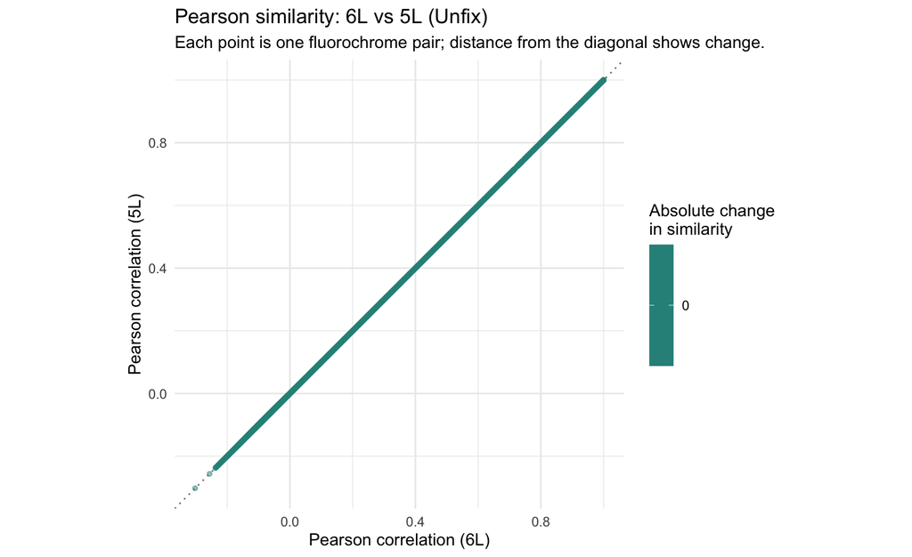

```r
ggplot(pearson_cmp, aes(Similarity_6L, Similarity_5L)) +
  geom_abline(slope = 1, intercept = 0, linetype = "dotted", color = "grey50") +
  geom_point(aes(color = abs(Difference)), alpha = 0.5, size = 1.2) +
  scale_color_viridis_c(name = "Absolute change\nin similarity") +
  coord_equal() +
  labs(title = sprintf("Pearson similarity: 6L vs 5L (%s)", default_treatment),
       subtitle = "Each point is one fluorochrome pair; distance from the diagonal shows change.",
       x = "Pearson correlation (6L)",
       y = "Pearson correlation (5L)")
```

## 1b-(ii) Spearman correlation: 6L vs 5L

**What this asks:** For each fluorochrome pair, does the similarity of the **ranked pattern** of detector signals stay the same between 6L and 5L?

Each point again represents one fluorochrome pair.

- A point on the diagonal means the pair has about the same Spearman correlation under 5L and 6L.
- A point away from the diagonal means the ranked spectral relationship changed with laser configuration.

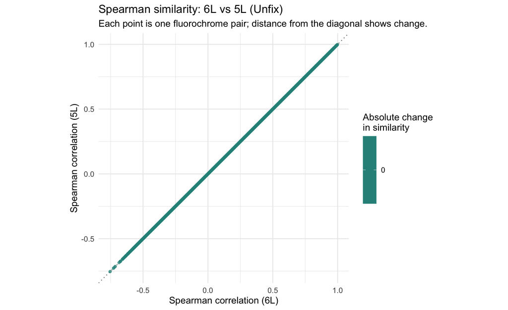

```r
ggplot(spearman_cmp, aes(Similarity_6L, Similarity_5L)) +
  geom_abline(slope = 1, intercept = 0, linetype = "dotted", color = "grey50") +
  geom_point(aes(color = abs(Difference)), alpha = 0.5, size = 1.2) +
  scale_color_viridis_c(name = "Absolute change\nin similarity") +
  coord_equal() +
  labs(title = sprintf("Spearman similarity: 6L vs 5L (%s)", default_treatment),
       subtitle = "Each point is one fluorochrome pair; distance from the diagonal shows change.",
       x = "Spearman correlation (6L)",
       y = "Spearman correlation (5L)")
```

## 1b-(iii) Cosine similarity: 6L vs 5L

**What this asks:** For each fluorochrome pair, does the overall **direction/shape** of the two spectral vectors remain equally similar between 6L and 5L?

Each point represents one fluorochrome pair.

- A point on the diagonal means cosine similarity stayed about the same.
- A point away from the diagonal means the overall spectral-vector similarity changed with laser configuration.

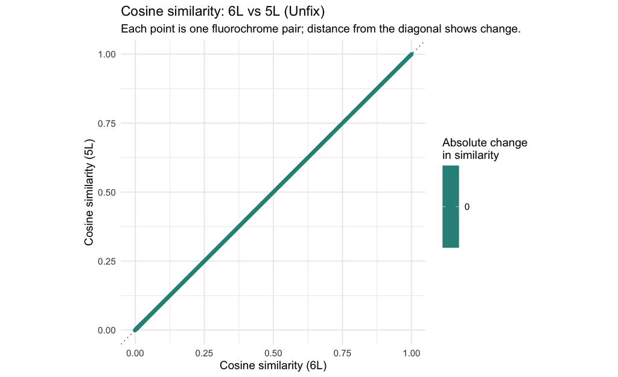

```r
ggplot(cosine_cmp, aes(Similarity_6L, Similarity_5L)) +
  geom_abline(slope = 1, intercept = 0, linetype = "dotted", color = "grey50") +
  geom_point(aes(color = abs(Difference)), alpha = 0.5, size = 1.2) +
  scale_color_viridis_c(name = "Absolute change\nin similarity") +
  coord_equal() +
  labs(title = sprintf("Cosine similarity: 6L vs 5L (%s)", default_treatment),
       subtitle = "Each point is one fluorochrome pair; distance from the diagonal shows change.",
       x = "Cosine similarity (6L)",
       y = "Cosine similarity (5L)")
```

## 1b-(iv) Compare the three similarity metrics

The Pearson, Spearman, and cosine results will be compared to determine whether they identify the same fluorochrome pairs as changing between 6L and 5L.

For each fluorochrome pair, the analysis will compare the absolute change in similarity:

`|5L similarity - 6L similarity|`

If all three metrics identify the same pair as changing strongly, that provides stronger evidence that its spectral relationship depends on laser configuration. If the metrics disagree, the pair can be inspected individually to understand why.

```r
metric_summary <- pairs_cmp_all |>
  filter(Treatment == default_treatment) |>
  mutate(Abs_change = abs(Difference)) |>
  group_by(Metric) |>
  summarise(
    Median_abs_change = median(Abs_change, na.rm = TRUE),
    Mean_abs_change = mean(Abs_change, na.rm = TRUE),
    Max_abs_change = max(Abs_change, na.rm = TRUE),
    .groups = "drop"
  )

kable(metric_summary,
      caption = "Overall change in pairwise similarity by metric for the example treatment.")
```

[output not shown]

## 1b-(v) Fluorochrome pairs with the largest changes

For each metric, rank fluorochrome pairs by the absolute difference between their 5L and 6L similarity values.

These are the pairs whose relationship changes the most when the laser configuration changes.

```r
movers_all <- pairs_cmp_all |>
  filter(Treatment == default_treatment) |>
  mutate(Abs_change = abs(Difference)) |>
  arrange(Metric, desc(Abs_change)) |>
  group_by(Metric) |>
  mutate(Change_rank = row_number()) |>
  ungroup() |>
  select(Metric, A, B, Similarity_6L, Similarity_5L,
         Difference, Abs_change, Change_rank)

datatable(movers_all, rownames = FALSE, filter = "top",
          extensions = "Buttons",
          caption = "Fluorochrome pairs ranked by 5L-vs-6L similarity change for Pearson, Spearman, and cosine.",
          options = list(pageLength = 15, scrollX = TRUE, dom = "Bfrtip",
                         buttons = c("copy", "csv", "excel")))
```

[output not shown]

# Aim 2 — Impact of fixation

The fixation analyses use **Unfixed as the reference**. Every treatment effect below is therefore a measured difference between the same fluorochrome under a treatment and under Unfixed. Analyses are performed separately by experiment and laser configuration.

## Question 2a — Overall impact of each treatment

**Exact comparison:** same fluorochrome under 1% PFA, 4% PFA, or Perm versus the same fluorochrome under Unfixed.

**How the effect is measured:** calculate RMSE, Pearson correlation, Spearman correlation, cosine similarity, maximum absolute detector difference, total intensity change, and peak shift for each treated-vs-Unfixed comparison. These are reported separately; they are not silently combined into one undefined “fixation effect.”

- RMSE summarizes overall spectral difference across channels.
- Pearson/Spearman/cosine quantify preservation of spectral pattern/shape.
- Maximum absolute difference identifies the largest single-channel change.
- Total intensity change measures overall gain/loss of signal.
- Peak shift measures movement of the highest spectral peak.

**How to interpret it:** larger distance/change measures or lower similarity to Unfixed indicate greater treatment-associated disruption. Treatments are compared across fluorochromes using each metric.

**Outputs:** treatment-effect tables, fluorochrome-by-treatment heatmaps, distributions of each metric by treatment, and treatment rankings.

## Question 2b — Which fluorochromes or fluorochrome types are most susceptible?

**Exact comparison:** use the measured treated-vs-Unfixed effects from 2a and compare them among fluorochromes.

**How susceptibility is measured:** rank fluorochromes using the actual 2a metrics. A fluorochrome with consistently high RMSE/other distance measures, large peak or intensity changes, and/or low treated-vs-Unfixed similarity is more fixation-sensitive. The analysis will retain the individual metrics so the reason a fluorochrome is flagged remains visible.

If the project team provides/approves classification metadata, the same measured effects can then be compared among fluorochrome groups. The classification scheme will not be assumed in advance.

**Outputs:** metric-specific susceptibility rankings, fluorochrome-by-treatment heatmaps, per-fluorochrome summaries, and group-level comparisons when classification metadata are available.

## Question 2c — Does laser configuration change the fixation effect?

**Exact comparison:** for the same fluorochrome and treatment, calculate the Treated-vs-Unfixed effect under 5L and the same Treated-vs-Unfixed effect under 6L, then compare them.

For RMSE, for example:

`5L fixation effect = RMSE(5L treated, 5L Unfixed)`

`6L fixation effect = RMSE(6L treated, 6L Unfixed)`

`configuration-dependent fixation effect = 6L RMSE - 5L RMSE`

The same comparison is performed **separately for each 2a metric**. Unlike metrics are not combined into one number. For Pearson/Spearman/cosine, lower similarity means greater spectral disruption; for RMSE and other distance/change measures, larger values mean greater disruption.

**How to interpret it:** a value near zero means fixation had a similar measured effect under 5L and 6L. A large difference means the effect of fixation depends on laser configuration for that fluorochrome/treatment. This directly addresses the **laser configuration × fixation treatment** interaction.

**Outputs:** metric-specific 5L-vs-6L effect scatterplots, treatment-by-configuration heatmaps, and rankings of the largest configuration-dependent fixation effects.

# Next step

The formal analysis will begin once the complete 5L dataset is received from the collaborators. The 5L data are required to perform and interpret the planned comparisons between the 5L and 6L instrument configurations.

Before analysis begins, the analysis plan will be reviewed and approved by the IDSS and CHI Flow Cytometry teams to confirm that the proposed methods appropriately address the project questions.

Once the analysis plan is approved and the required Excel files are available, the work is expected to proceed over approximately two weeks:

Start Week 1 — Question 1: Instrument configuration. Complete the 5L vs. 6L analyses, including peak-shift analysis and evaluation of fluorochrome similarity using Pearson, Spearman, and cosine similarity. Start Week 2 — Question 2: Fixation. Complete the analyses of overall fixation effects, fluorochrome susceptibility, and whether fixation effects differ between the 5L and 6L configurations.

IDSS will perform the analysis internally using the Shiny application for data input, exploration, and analysis, together with the formal QMD workflow for reproducible analysis and report generation. A standalone QMD file will be maintained so that the complete analysis can also be run independently of the Shiny application.

After the results have been generated and internally reviewed, the final QMD report and analysis outputs will be provided to the collaborators.

**Important**

**Please make sure any requested changes, decisions, or updates is done by email or text from the PI so they can be clearly tracked. Changes discussed during meetings or verbal conversations is harder/impossible to track and reference later.**

```
Preprocessing: Raw values
6L file: Compiled_matrixes_6L_treatments.xlsx
5L file: Compiled_matrixes_5L_treatments_PLACEHOLDER.xlsx
```